# **HÁBITOS DE HIDRATACIÓN EN ESTUDIANTES DE LA UTEC EN ABRIL DEL 2023**

# 1 **Introducción**

## 1.1 Relevancia

Diversas investigaciones han comprobado que tanto la deshidratación como la hiperhidratación en niveles leves y moderados pueden tener efectos perjudiciales en el rendimiento académico y en la salud, tanto física como mental, de las personas. Dado que el bienestar de los estudiantes es de suma importancia, consideramos que este estudio puede proporcionar información relevante sobre este tema crucial.

## 1.2 Contexto

En este estudio, se pretende analizar la calidad de los hábitos de hidratación de los estudiantes de la UTEC, con el objetivo de proporcionar una fuente actualizada de información que ayude a la institución educativa a tomar medidas para mejorar dichos hábitos. Este enfoque no solo busca favorecer la salud de los alumnos, sino también potenciar su rendimiento académico.

## 1.3 Objetivos:

### 1.3.1 Objetivo general:

- Identificar los hábitos de hidratación en los estudiantes de la UTEC en abril del 2023

### 1.3.2 Objetivos específicos:

**Estos objetivos serán analizados por género**

- Determinar que tipo de líquido es ingerido en mayor proporción y los impactos que cada una de estas bebidas tiene en los estudiantes
- Estimar los posibles efectos negativos de una mala hidratación en la salud física en los estudiantes
- Analizar la posible relación de altos niveles de ansiedad y estrés en estudiantes con malos hábitos de hidratación
- Analizar la percepción de los estudiantes acerca de sus hábitos de hidratación en este semestre

# 2 **Datos:**

## 2.1 Recolección de datos

La recolección de datos se realizó por medio del **muestreo por conveniencia** con la ayuda de la herramienta **Google Forms**, donde se elaboró una encuesta con preguntas generales y específicas relevantes con sus respectivas restricciones para el proyecto, de modo que sean de fácil comprensión para **los estudiantes de UTEC 2023-1**. Esta encuesta se desarrolló en una semana y tres días, se divulgó por diferentes redes sociales, como WhatsApp e Instagram. Además, los integrantes del grupo se repartieron en los diferentes pisos de UTEC y emplearon el código QR de la encuesta, para conseguir más respuestas de forma directa. Finalmente, el grupo alcanzó a recolectar **202** respuestas y procedieron a la limpieza de datos.

## 2.2 Herramienta de recolección de datos:

Encuesta de hábitos de hidratación en alumnos de la UTEC en abril del 2023: link

## 2.3 Población, muestra y muestreo:

[output not shown]

## 2.4 Variables utilizadas:

Resumen de las variables

| Variable | Clase | Descripción |
| --- | --- | --- |
| Edad | Numérica discreta | Restricción: ser un número entero positvo del 10 al 39 |
| Género | Categórica nominal | Opcion única: “femenino”, “masculino” y “otro” |
| Peso | Numérica continua | Restricción: ser un número entre 35 - 200 kilos |
| Estatura | Numérica continua | Restricción: ser un número entre 1.20 - 2.20 metros |
| Carrera | Categórica nominal | Opcion única: carreras presentes en la UTEC |
| Ciclo | Categórica ordinal | Opcion única: ciclos del 1 - 10 |
| Litros_por_dia | Numérica continua | Restricción: valor fraccionario del 0.1 - 6 |
| Tipos_liquido | Categórica nominal | Opcion múltiple: “Agua”, “Gaseosas”, “Refrescos o jugos”, “Bebidas energizantes”, “Infusiones” y “Otro” |
| Litros_clase | Numérica continua | Restricción: valor fraccionario del 0.1 - 6. |
| Sed_clase | Categórica ordinal | Opción única: donde 1 representa “Muy poca sed” y 5 “Mucha sed” |
| Agua_clase | Categórica ordinal | Opción única: donde 1 representa “Nunca” y 5 “Siempre” |
| Gaseosas_clase | Categórica ordinal | Opción única: donde 1 representa “Nunca” y 5 “Siempre” |
| Bebidas_energeticas_clase | Categórica ordinal | Opción única: donde 1 representa “Nunca” y 5 “Siempre” |
| Infusiones_clase | Categórica ordinal | Opción única: donde 1 representa “Nunca” y 5 “Siempre” |
| Cansado_tipo_liquido | Categórica nominal | Opcion única: “Agua”, “Gaseosas”, “Refrescos o jugos”, “Bebidas energizantes”, “Infusiones” y “Otro” |
| Liquido_mejora_rendimiento | Categórica nominal | Opcion única: “Agua”, “Gaseosas”, “Refrescos o jugos”, “Bebidas energizantes”, “Infusiones” y “Otro” |
| Rendimiento_hidratado | Categórica nominal | Opción única: “Sí”, “No” y “Tal vez” |
| Concentracion_clase | Categórica ordinal | Opción única: donde 1 representa “No me concentro en lo absoluto” y 5 “Me concentro completamente” |
| Memoria | Categórica ordinal | Opción única: donde 1 representa “Muy mala” y 5 “Muy buena” |
| Deshidratacion_efectos | Categórica nominal | Opción única: “Sí”, “No” y “Tal vez” |
| Salud_fisica | Categórica ordinal | Opción única: donde 1 representa “Nada saludable” y 5 “Muy saludable” |
| Migrañas | Categórica ordinal | Opción única: donde 1 representa “Nunca” y 5 “Siempre” |
| Fatiga | Categórica ordinal | Opción única: donde 1 representa “Nunca” y 5 “Siempre” |
| Salud_mental | Categórica ordinal | Opción única: donde 1 representa “Muy mala” y 5 “Muy buena” |
| Ansiedad | Categórica nominal | Opción única: “Sí” y “No” |
| Estres | Categórica nominal | Opción única: “Sí” y “No” |
| CF_no_ingesta_liquido | Categórica nominal | Opción única: “Sí”, “No” y “A veces” |
| Horas_en_universidad | Numérica discreta | Restricción: ser un número entero positivo entre 2 - 59 |
| Cantidad_cursos | Numérica discreta | Opcion única: valores del 1 al 8 |

## 2.5 Limpieza de datos

Se importa la base de datos con el nombre de Bdatos:

```r
Bdatos<- read_csv("Habitos_de_hidratacion.csv")
```

### 2.5.1 Renombrando y recategorizando variables:

#### 2.5.1.1 Renombrando variables:

```r
Bdatos = rename(Bdatos, Edad = "Edad:", Género = "Género:", Carrera = "Carrera:", Peso = "Peso:", Estatura = "Estatura:")


Bdatos = rename(Bdatos, Ciclo = "¿En qué ciclo se encuentra según la definición de UTEC?")

Bdatos = rename(Bdatos, Litros_por_dia = "¿Cuántos litros de líquido consume al día aproximadamente?")

Bdatos = rename(Bdatos, Tipos_liquido = "¿Qué tipo de líquidos consume al día?")

Bdatos = rename(Bdatos, Litros_clase = "¿Cuántos litros de líquido consume en horario de clases aproximadamente?")

Bdatos = rename(Bdatos, Sed_clase = "En una escala del 1 al 5 ¿Cuánta sed presenta durante las horas de clase?")

Bdatos = rename(Bdatos, Agua_clase = "En una escala del 1 al 5  ¿Con qué frecuencia consume agua en sus clases?")

Bdatos = rename(Bdatos, Gaseosas_clase = "En una escala del 1 al 5  ¿Con qué frecuencia consume gaseosas en sus clases?")

Bdatos = rename(Bdatos,  Bebidas_energeticas_clase= "En una escala del 1 al 5  ¿Con qué frecuencia consume bebidas energéticas en sus clases?")

Bdatos = rename(Bdatos,  Infusiones_clase= "En una escala del 1 al 5  ¿Con qué frecuencia consume infusiones en sus clases?")

Bdatos = rename(Bdatos,  Cansado_tipo_liquido= "¿Qué tipo de bebida prefiere ingerir cuando se siente cansado durante clases?")

Bdatos = rename(Bdatos,  Liquido_mejora_rendimiento= "¿Qué tipo de bebida considera que ayuda a mejorar su rendimiento académico durante clases?")

Bdatos = rename(Bdatos,  Rendimiento_hidratado= "¿Considera que el mantenerse hidratado afecta en su rendimiento académico?")

Bdatos = rename(Bdatos,  Concentracion_clase= "¿Qué tan bien se concentra durante clases?")

Bdatos = rename(Bdatos,  Memoria= "¿Qué tan buena es su memoria?")

Bdatos = rename(Bdatos,  Deshidratacion_efectos= "¿Usted considera que la deshidratación afecta en sus funciones cognitivas como atención y concentración?")

Bdatos = rename(Bdatos,  Salud_fisica= "Respecto a su salud física,  en una escala del 1 al 5  que tan saludable considera que es:")

Bdatos = rename(Bdatos,  Migrañas= "En una escala del 1 al 5  ¿Con que frecuencia presenta migrañas?")

Bdatos = rename(Bdatos,  Fatiga= "En una escala del 1 al 5 ¿Con qué frecuencia presenta una sensación de fatiga?")

Bdatos = rename(Bdatos,  Salud_mental= "Respecto a su salud mental, en una escala del 1 al 5 considera que es...")

Bdatos = rename(Bdatos,  Ansiedad= "¿Presenta altos niveles de ansiedad?")

Bdatos = rename(Bdatos,  Estres= "¿Presenta altos niveles de estrés?")

Bdatos = rename(Bdatos,  CF_no_ingesta_liquido= "¿Usted considera que se siente cansado o fatigado cuando no consume líquidos con frecuencia?")

Bdatos = rename(Bdatos,  Horas_en_universidad= "¿Cuántas horas a la semana pasa dentro de la universidad?")

Bdatos = rename(Bdatos,  Cantidad_cursos= "¿En cuántos cursos se encuentra matriculado en este ciclo 2023-1?")
```

#### 2.5.1.2 Recategorizando valores en variables:

```r
Bdatos$Sed_clase = recode(Bdatos$Sed_clase, '1'="Muy poca", '2'="Poca", '3'="Ni mucha ni poca", '4'="Moderada", '5'= "Mucha")

Bdatos$Agua_clase = recode(Bdatos$Agua_clase, '1'="Nunca", '2'="Casi nunca", '3'="A veces", '4'="Casi siempre", '5'= "Siempre")

Bdatos$Gaseosas_clase = recode(Bdatos$Gaseosas_clase, '1'="Nunca", '2'="Casi nunca", '3'="A veces", '4'="Casi siempre", '5'= "Siempre")

Bdatos$Bebidas_energeticas_clase = recode(Bdatos$Bebidas_energeticas_clase, '1'="Nunca", '2'="Casi nunca", '3'="A veces", '4'="Casi siempre", '5'= "Siempre")

Bdatos$Infusiones_clase = recode(Bdatos$Infusiones_clase, '1'="Nunca", '2'="Casi nunca", '3'="A veces", '4'="Casi siempre", '5'= "Siempre")

Bdatos$Concentracion_clase = recode(Bdatos$Concentracion_clase, '1'="Nunca", '2'="Casi nunca", '3'="A veces", '4'="Casi siempre", '5'= "Siempre")

Bdatos$Memoria = recode(Bdatos$Memoria, '1'="Muy mala", '2'="Mala", '3'="Ni buena ni mala", '4'="Buena", '5'= "Muy buena")


Bdatos$Salud_fisica = recode(Bdatos$Salud_fisica, '1'="Nada saludable", '2'="Poco saludable", '3'="Medianamente saludable", '4'="Saludable", '5'= "Muy saludable")


Bdatos$Migrañas = recode(Bdatos$Migrañas, '1'="Nunca", '2'="Casi nunca", '3'="A veces", '4'="Casi siempre", '5'= "Siempre")


Bdatos$Fatiga = recode(Bdatos$Fatiga, '1'="Nunca", '2'="Casi nunca", '3'="A veces", '4'="Casi siempre", '5'= "Siempre")


Bdatos$Salud_mental = recode(Bdatos$Salud_mental, '1'="Muy mala", '2'="Mala", '3'="Ni buena ni mala", '4'="Buena", '5'= "Muy buena")
```

### 2.5.2 Eliminación de ciertas variables:

Se eliminan las variables que no serán necesarias (Marca temporal, correo electrónico y una pregunta eliminada que se había quedado dentro de la base de datos).

```r
Bdatos <- Bdatos[ , -c(1:4,20)]
#1 = Marca temporal
#2 = Dirección de correo electrónico
#3 = Nombres
#4 = Apellidos
#20 = Respecto a la pregunta anterior, justifique brevemente su respuesta (esta pregunta no fue utilizada a la hora de encuestar).
```

### 2.5.3 Diferenciación de datos enteros y decimales:

```r
Bdatos$Cantidad_cursos = as.integer(Bdatos$Cantidad_cursos)
Bdatos$Edad = as.integer(Bdatos$Edad)
Bdatos$Horas_en_universidad = as.integer(Bdatos$Horas_en_universidad)
```

### 2.5.4 Identificación y modificación de datos errados:

#### 2.5.4.1 Datos con decimales en la edad:

Todas las edades se redondean al entero más próximo, pues existían dos datos en la base que presentaban decimales (dichas décimas eran menores a 0.5).

```r
Bdatos$Edad = round(Bdatos$Edad)
```

#### 2.5.4.2 Datos de cantidad de líquidos ingeridos errados por problema en los formatos y problemas de inconsistencias:

Debido a un error de formatos entre el formulario y el archivo .csv, se procedió a dividir entre mil los datos que se pusieron de forma errónea en la base de datos.

```r
filter(Bdatos, Litros_por_dia>6)
```

```
## # A tibble: 1 x 29
##    Edad Género Carrera Ciclo Litros_por_dia Tipos_liquido Litros_clase Sed_clase
##   <dbl> <chr>  <chr>   <chr>          <dbl> <chr>                <dbl> <chr>
## 1    18 Femen~ Ingeni~ Terc~            500 Agua, Refres~          0.5 Poca
## # i 21 more variables: Agua_clase <chr>, Gaseosas_clase <chr>,
## #   Bebidas_energeticas_clase <chr>, Infusiones_clase <chr>,
## #   Cansado_tipo_liquido <chr>, Liquido_mejora_rendimiento <chr>,
## #   Rendimiento_hidratado <chr>, Concentracion_clase <chr>, Memoria <chr>,
## #   Deshidratacion_efectos <chr>, Salud_fisica <chr>, Migrañas <chr>,
## #   Fatiga <chr>, Salud_mental <chr>, Ansiedad <chr>, Estres <chr>,
## #   CF_no_ingesta_liquido <chr>, Peso <dbl>, Estatura <dbl>, ...
```

```r
filter(Bdatos, Litros_clase>6)
```

```
## # A tibble: 1 x 29
##    Edad Género Carrera Ciclo Litros_por_dia Tipos_liquido Litros_clase Sed_clase
##   <dbl> <chr>  <chr>   <chr>          <dbl> <chr>                <dbl> <chr>
## 1    17 Mascu~ Ingeni~ Terc~            2.5 Agua, Gaseos~          675 Moderada
## # i 21 more variables: Agua_clase <chr>, Gaseosas_clase <chr>,
## #   Bebidas_energeticas_clase <chr>, Infusiones_clase <chr>,
## #   Cansado_tipo_liquido <chr>, Liquido_mejora_rendimiento <chr>,
## #   Rendimiento_hidratado <chr>, Concentracion_clase <chr>, Memoria <chr>,
## #   Deshidratacion_efectos <chr>, Salud_fisica <chr>, Migrañas <chr>,
## #   Fatiga <chr>, Salud_mental <chr>, Ansiedad <chr>, Estres <chr>,
## #   CF_no_ingesta_liquido <chr>, Peso <dbl>, Estatura <dbl>, ...
```

```r
Bdatos[45,5] <- (Bdatos[45,5])/1000
#Este dato aparecía como 0.500 en el formulario; sin embargo, en la base de datos aparecía como 500.
```

```r
Bdatos[142,7] <- (Bdatos[142,7])/1000
#Este dato aparecía como 0.675 en el formulario; sin embargo, en la base de datos aparecía como 675.
```

- **Consideraciones para eliminar observaciones**: inconsistencias entre variables.

Se puede notar que existen inconsistencias respecto a la cantidad de litros que consumen los estudiantes por día y las que consumen por clase. Es por ello que se decidió eliminar dichos datos, pues no son representativos y podrían alterar los resultados del estudio.

```r
Bdatos <- filter(Bdatos, !(Litros_clase>Litros_por_dia))
```

**Se trabajarán con 189 observaciones limpias y prolijas.**

### 2.5.5 Creación de nuevas variables para pregunta de opción múltiple:

La variable *tipo_liquido* fue una pregunta de opción múltiple, por lo tanto se crearán nuevas variables para cada posible respuesta. En este caso, las variables tendrán como posibles valores TRUE, en el caso de que consuman ese tipo de líqudio o FALSE. Asimismo, la variable *tipo_liquido* será eliminada posteriormente.

```r
suppressMessages({
Bdatos = (Bdatos %>%
    separate_rows(Tipos_liquido, sep=", ") %>%
    mutate(value=TRUE) %>%
    spread(Tipos_liquido, value, fill=FALSE) %>%
    left_join(Bdatos))

Bdatos = (Bdatos %>% select(-Tipos_liquido))})
```

```r
#Se cambian los valores de True y False por Sí y No respectivamente

Bdatos$Agua <- ifelse(Bdatos$Agua, "Sí", "No")

Bdatos$Infusiones <- ifelse(Bdatos$Infusiones, "Sí", "No")

Bdatos$Gaseosas <- ifelse(Bdatos$Gaseosas, "Sí", "No")

Bdatos$`Bebidas energizantes` <- ifelse(Bdatos$`Bebidas energizantes`, "Sí", "No")

Bdatos$`Refrescos o jugos` <- ifelse(Bdatos$`Refrescos o jugos`, "Sí", "No")

Bdatos$Otro <- ifelse(Bdatos$Otro, "Sí", "No")
```

### 2.5.6 Número de casos completos e incompletos:

```r
sum(complete.cases(Bdatos)) #Casos completos
```

```
## [1] 189
```

```r
sum(!complete.cases(Bdatos)) #Casos incompletos
```

```
## [1] 0
```

```r
#Todos los datos están completos (100%).
```

### 2.5.7 Datos totales

```r
ncol(Bdatos)*nrow(Bdatos)
```

```
## [1] 6426
```

# 3 **Análisis descriptivo**

Se utilizarán las siguientes funciones:

- Función para hallar el coeficiente de variación

```r
CV <- function(x) {
  return (sd(x) / mean(x))
}
```

- Función que retorna los descriptores de la variable deseada.

```r
resumen <- function(x) {
  return (c("Min"=min(x),"Max"=max(x),"Media"=mean(x), "Mediana"=median(x), "Desviación Estándar"=sd(x), "Coeficiente de Variación"=CV(x), "Rango Intercuartil"=IQR(x)))
}
```

### 3.0.1 Análisis general de la base de datos (univariado):

Este análisis se hace con el fin de entender la distribución presente de los datos recolectados, pues de esa manera se podrá conocer que tan representativos serán los resultados que se obtendrán.

**Carrera**

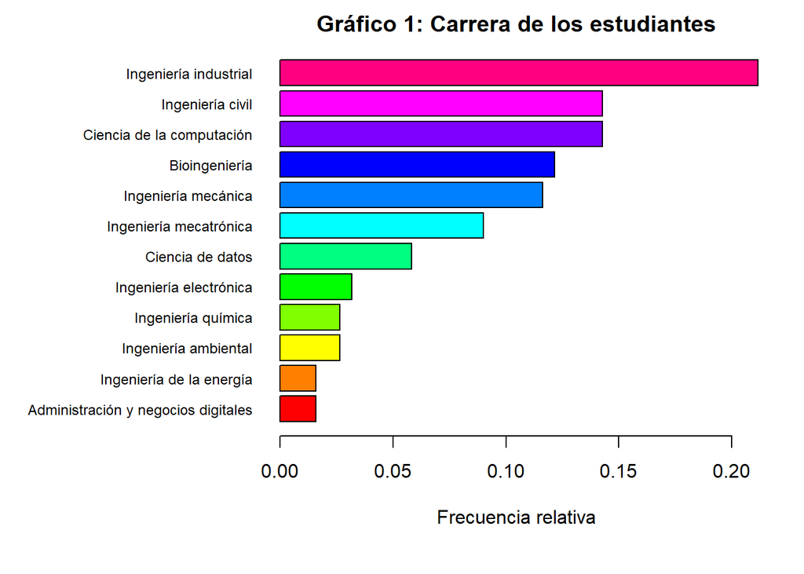

```r
par(mar=c(6,12,2,2))
barplot(sort(table(Bdatos$Carrera))/nrow(Bdatos),xlab = "Frecuencia relativa",cex.names=0.75,cex.axis =1, las=1,main = "Gráfico 1: Carrera de los estudiantes", col = rainbow(12), horiz =TRUE)
```

Se presentan a alumnos de Ingeniería Industrial en mayor cantidad y pocos alumnos de Administración y Negocions digitales e Ingeniería de la Energía.

**Ciclo**

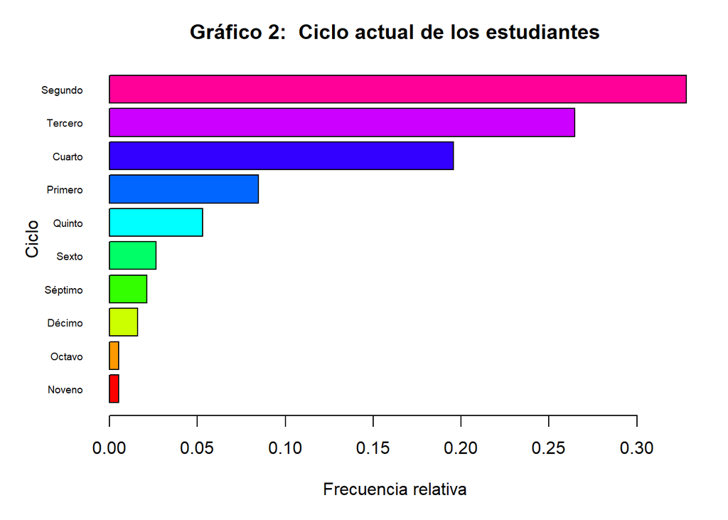

```r
par(mar=c(5,5,3,2))
barplot(sort(table(Bdatos$Ciclo))/nrow(Bdatos),xlab = "Frecuencia relativa",cex.names=0.6,cex.axis =1, las=1,main = "Gráfico 2:  Ciclo actual de los estudiantes", horiz =TRUE, col = rainbow(10), ylab = "Ciclo")
```

Se puede notar que la gran mayoría de las observaciones pertenecen a alumnos de segundo, tercer y cuarto ciclo.

**Cantidad de cursos**

Se analizará si la variable presenta posibles datos atípicos:

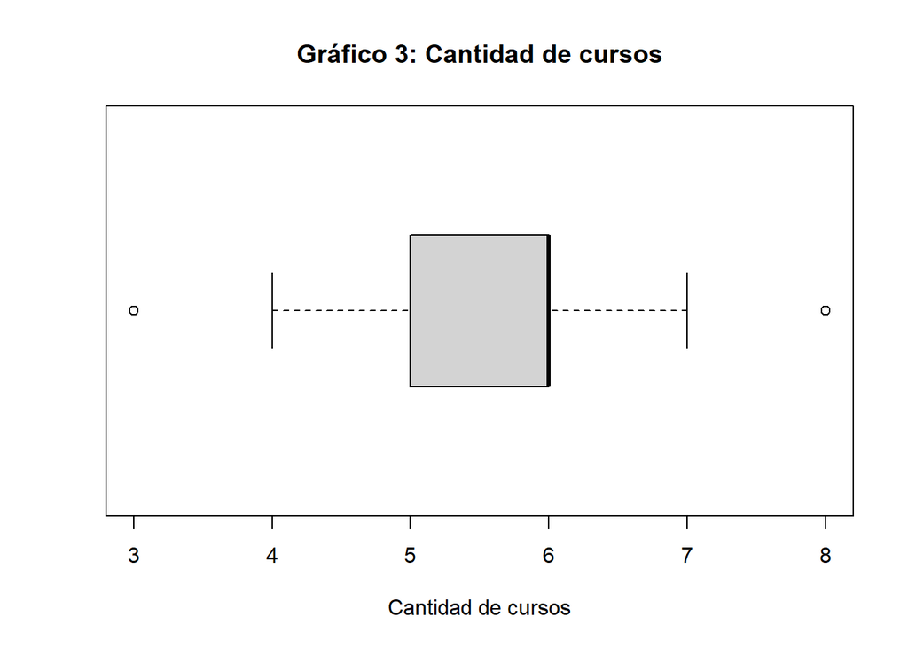

```r
boxplot(Bdatos$Cantidad_cursos, main= "Gráfico 3: Cantidad de cursos", horizontal = T, xlab = "Cantidad de cursos")
```

Existen como mínimo 2 datos atípicos para esta variable, pero estos se encuentran dentro de los límites establecidos para la variable.

Se creará un histograma para apreciar mejor la distribución de los datos presentes para esta variable:

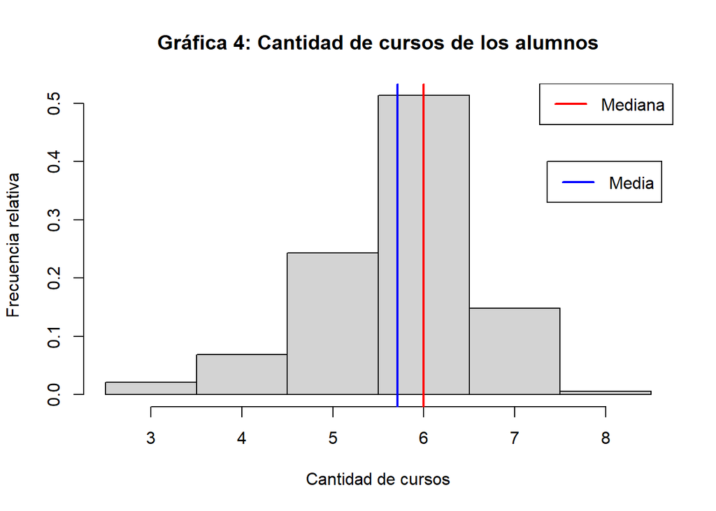

```r
hist(Bdatos$Cantidad_cursos, ylab = "Frecuencia relativa", probability = T, xlab = "Cantidad de cursos", main ="Gráfica 4: Cantidad de cursos de los alumnos", breaks =(min(Bdatos$Cantidad_cursos):(max(Bdatos$Cantidad_cursos) + 1)) - 0.5)

abline(v = median(Bdatos$Cantidad_cursos), col = "red", lwd = 2)

legend("topright", legend="Mediana", col="red", lwd=2)


abline(v = mean(Bdatos$Cantidad_cursos), col = "blue", lwd = 2)
legend(x = 7.36, y = 0.4 , legend="Media", col="blue", lwd=2)
```

La distribución está ligeramente sesgada hacia la izquierda, pues la mediana es mayor a la media. Asimismo, son 6 los cursos que están llevando al menos la mitad de los alumnos.

*Algunos descriptores:*

```r
Bdatos$Cantidad_cursos %>% resumen
```

```
##                      Min                      Max                    Media
##                3.0000000                8.0000000                5.7142857
##                  Mediana      Desviación Estándar Coeficiente de Variación
##                6.0000000                0.8949368                0.1566139
##       Rango Intercuartil
##                1.0000000
```

Se puede apreciar que la dispersión de los datos es relativamente baja gracias al coeficiente de variación.

**Edad**

Se analizará si la variable presenta algún dato atípico:

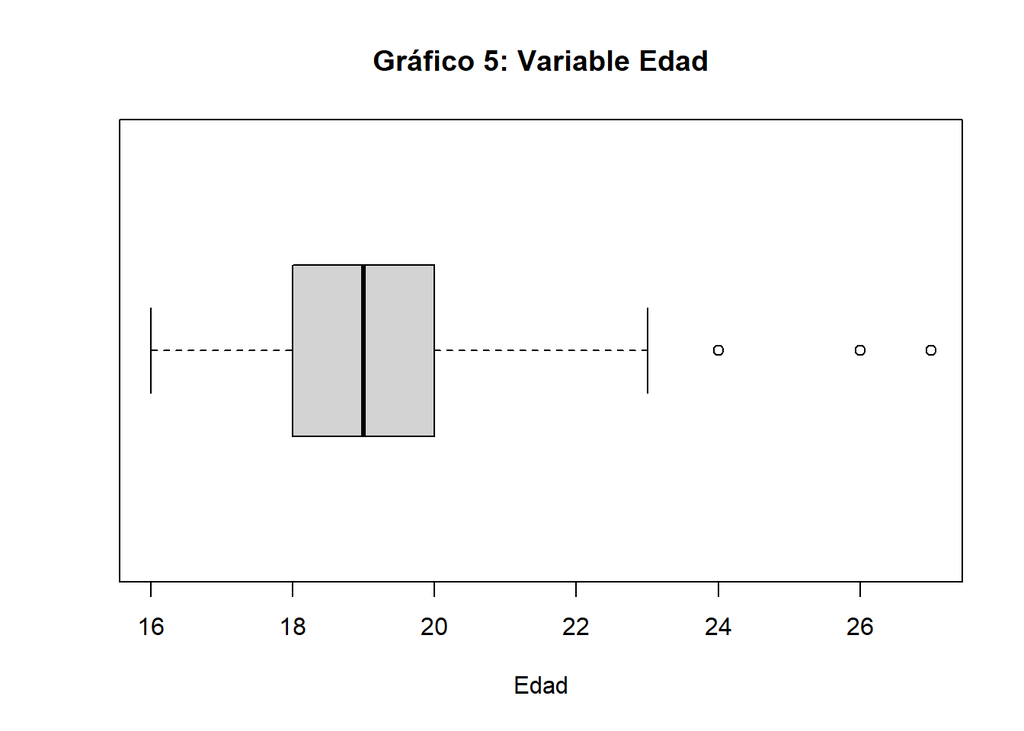

```r
boxplot(Bdatos$Edad, main="Gráfico 5: Variable Edad", horizontal = T, xlab = "Edad")
```

Existen como mínimo tres datos atípicos en la variable Edad.

Se creará un histograma para notar la distribución que presenta esta variable:

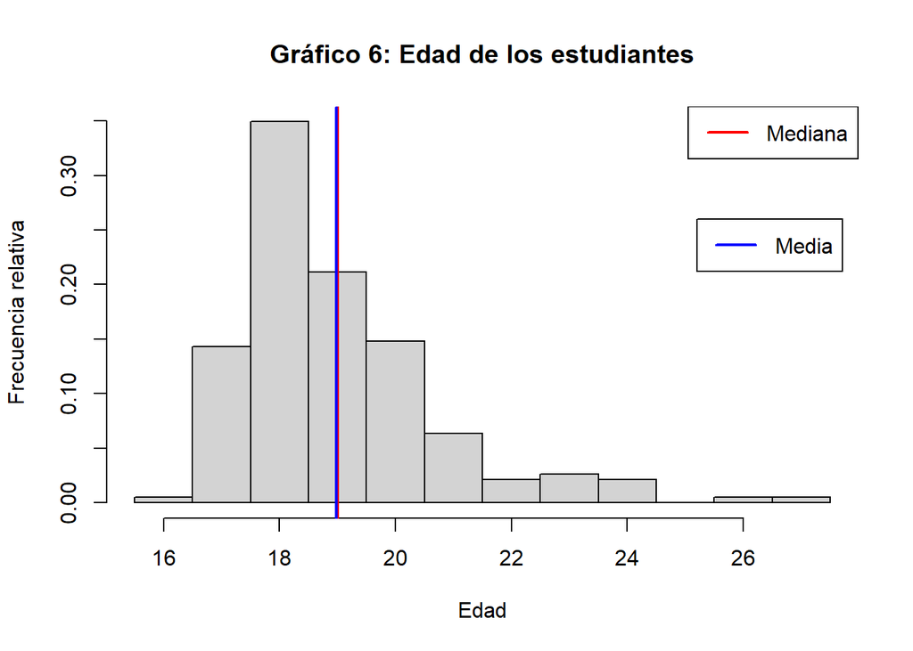

```r
hist(Bdatos$Edad, ylab = "Frecuencia relativa", probability = T, xlab = "Edad", main ="Gráfico 6: Edad de los estudiantes", breaks =(min(Bdatos$Edad):(max(Bdatos$Edad) + 1)) - 0.5)

abline(v = median(Bdatos$Edad), col = "red", lwd = 2)

legend("topright", legend="Mediana", col="red", lwd=2)

abline(v = mean(Bdatos$Edad), col = "blue", lwd = 2)
legend(x = 25.2, y = 0.26 , legend="Media", col="blue", lwd=2)
```

*Algunos descriptores:*

```r
Bdatos$Edad %>% resumen
```

```
##                      Min                      Max                    Media
##              16.00000000              27.00000000              18.97883598
##                  Mediana      Desviación Estándar Coeficiente de Variación
##              19.00000000               1.76839172               0.09317704
##       Rango Intercuartil
##               2.00000000
```

Se puede notar que, efectivamente, la media y mediana tienen valores cercanos cuando no se ignoran los datos atípicos.

**Género**

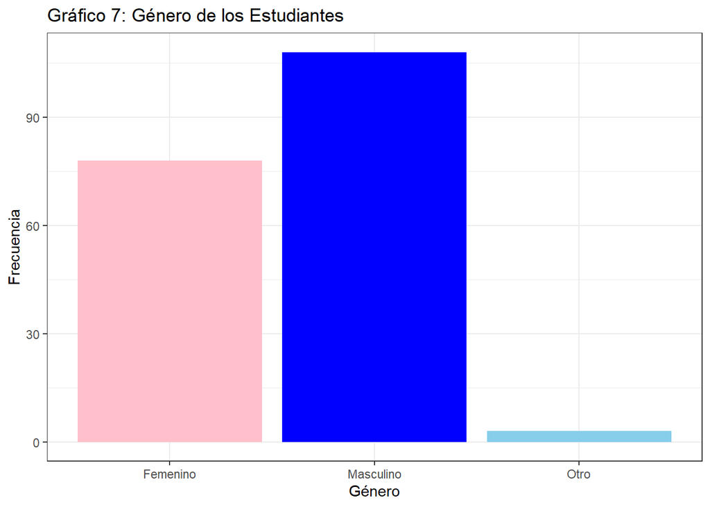

```r
ggplot(Bdatos, aes(x = Género)) + geom_bar(width = 0.9,  fill=c("pink","blue","skyblue")) + scale_x_discrete("Género") +  scale_y_continuous("Frecuencia") + labs(title = "Gráfico 7: Género de los Estudiantes") + theme_bw(base_size = 11)
```

Se puede notar que existen más alumnos de género masculino. A partir de ello, **se hará un analisis por género** para obtener resultados mas representativos.

#### 3.0.1.1 Correlación de variables numéricas

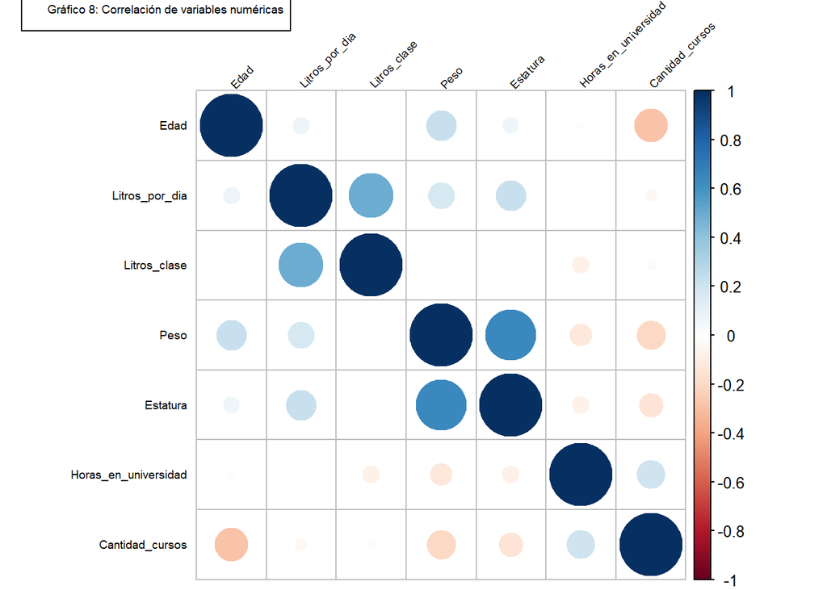

```r
bdc <- Bdatos %>% select(Edad, Litros_por_dia, Litros_clase, Peso, Estatura, Horas_en_universidad, Cantidad_cursos)

corrplot(cor(bdc, use = "complete.obs"), tl.cex = 0.6, tl.srt = 45, tl.col = "black")
legend(x = -2, y = 9, legend="Gráfico 8: Correlación de variables numéricas", cex = 0.6)
```

De esta gráfica se puede concluir que:

- Existe una correlación positiva y alta entre las variables *Peso* y *Estatura*.
- Existe una correlación positiva entre las variables *Litros_por_dia* y *Litros_clase*.
- Existe una correlación positiva entre las variables *Estatura* y *Litros_por_dia*.
- Existe una correlación negativa entre las variables *Cantidad_cursos* y *Edad*.
- Existe una correlación negativa entre *Cantidad_cursos* y *Peso*.

Dichas relaciones no son tan relevantes para el análisis, con excepción de:

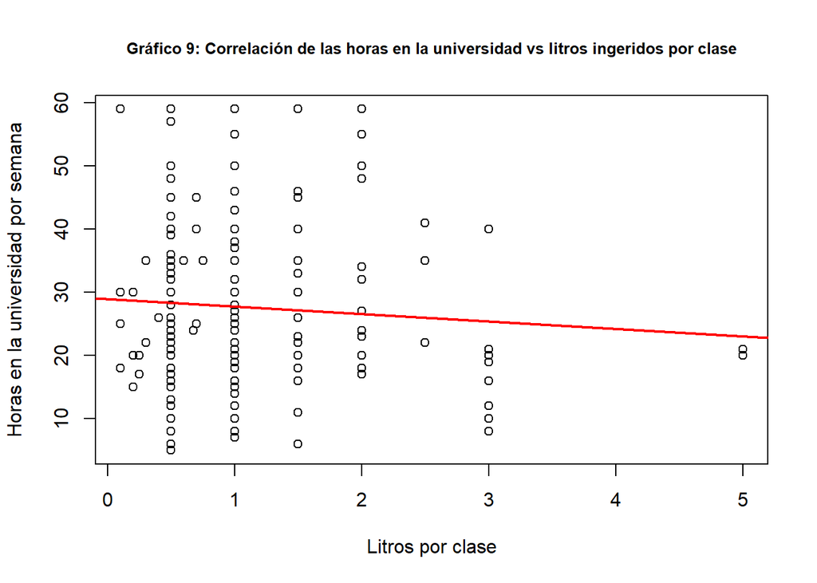

```r
plot(Bdatos$Horas_en_universidad~ Bdatos$Litros_clase, ylab = "Horas en la universidad por semana", xlab = "Litros por clase", main = "Gráfico 9: Correlación de las horas en la universidad vs litros ingeridos por clase",cex.main=0.8)

abline(lm(Bdatos$Horas_en_universidad ~ Bdatos$Litros_clase), col="red", lwd=2)
```

Se puede notar que mientras menos horas en la universidad pasan los alumnos, más litros de líquido consumen.

### 3.0.2 Análisis bivariado:

Se tratará de identificar los hábitos de hidratación por género mediante ciertas relaciones entre las variables que se poseen. Estas relaciones serán:

- (Litros_por_dia - Género)
- (Litros_clase - Género)
- (Tipos_liquido (derivados) - Género)
- (Agua_clase - Género), (Gaseosas_clase - Género), (Bebidas_energeticas_clase - Género), (Infusiones_clase - Género)
- (Cansado_tipo_liquido - Género)
- (Liquido_mejora_rendimiento - Género)

#### 3.0.2.1 *Primera relación -> (Litros_por_dia - Género)*:

Mediante un “boxplot” se hallará la posible existencia de datos atípicos en esta relación:

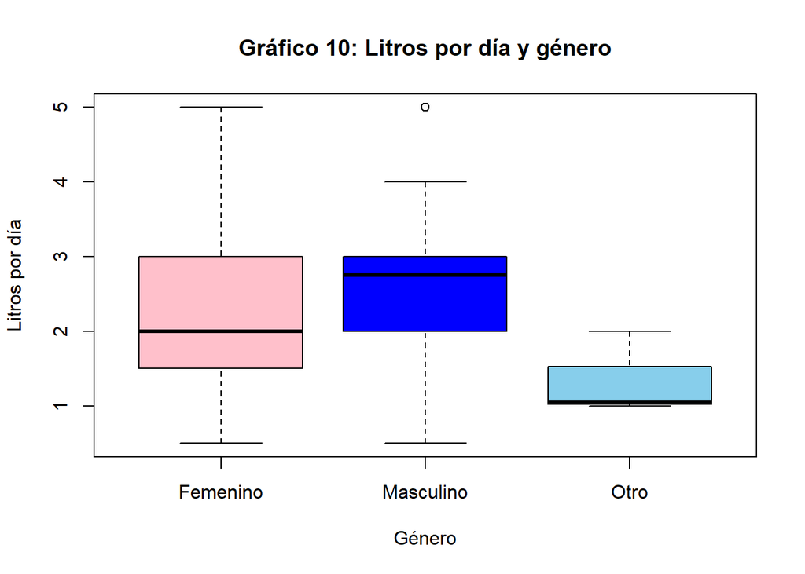

```r
boxplot(Bdatos$Litros_por_dia~Bdatos$Género, xlab = "Género", ylab = "Litros por día", main = "Gráfico 10: Litros por día y género",col=c("pink","blue","skyblue"))
```

Existe como mínimo un caso atípico en esta relación con respecto al género masculino. Por ende, no sería muy recomendable utilizar la media, ya que dicho descriptor es sensible a datos extremos. Por ello, se utilizarán descriptores más robustos como la mediana y moda.

Se presentarán dos tablas para notar la mediana y moda de los litros consumidos por día respecto a cada género:

```r
by(Bdatos$Litros_por_dia,Bdatos$Género,median)
```

```
## Bdatos$Género: Femenino
## [1] 2
## ------------------------------------------------------------
## Bdatos$Género: Masculino
## [1] 2.75
## ------------------------------------------------------------
## Bdatos$Género: Otro
## [1] 1.05
```

```r
by(Bdatos$Litros_por_dia,Bdatos$Género,Mode)
```

```
## Bdatos$Género: Femenino
## [1] 2
## ------------------------------------------------------------
## Bdatos$Género: Masculino
## [1] 3
## ------------------------------------------------------------
## Bdatos$Género: Otro
## [1] NA
```

Dentro de la base de datos, solo existen 3 alumnos que presentan como género a “Otro”:

```r
Bdatos %>% filter(Género=="Otro")
```

```
## # A tibble: 3 x 34
##    Edad Género Carrera    Ciclo Litros_por_dia Litros_clase Sed_clase Agua_clase
##   <dbl> <chr>  <chr>      <chr>          <dbl>        <dbl> <chr>     <chr>
## 1    23 Otro   Ingenierí~ Quin~           1.05          0.5 Ni mucha~ A veces
## 2    18 Otro   Ciencia d~ Cuar~           1             1   Ni mucha~ Casi siem~
## 3    17 Otro   Ciencia d~ Prim~           2             1   Moderada  Siempre
## # i 26 more variables: Gaseosas_clase <chr>, Bebidas_energeticas_clase <chr>,
## #   Infusiones_clase <chr>, Cansado_tipo_liquido <chr>,
## #   Liquido_mejora_rendimiento <chr>, Rendimiento_hidratado <chr>,
## #   Concentracion_clase <chr>, Memoria <chr>, Deshidratacion_efectos <chr>,
## #   Salud_fisica <chr>, Migrañas <chr>, Fatiga <chr>, Salud_mental <chr>,
## #   Ansiedad <chr>, Estres <chr>, CF_no_ingesta_liquido <chr>, Peso <dbl>,
## #   Estatura <dbl>, Horas_en_universidad <int>, Cantidad_cursos <int>, ...
```

Para estos tres alumnos, no hay un valor repetido en la cantidad de litros que ingieren. Es por ello que la moda toma como valor NA.

Se puede notar que los resultados obtenidos con estas medidas de resumen no están muy alejados. Además, se pude ver que existe una diferencia en la cantidad de litros consumidos al día por género, donde el género masculino tiende a tomar un poco más de líquidos al día que el género femenino.

#### 3.0.2.2 *Segunda relación -> (Litros_clase - Género)*:

Se tratará de determinar la posible diferencia en los litros de líquidos consumidos durante los horarios de clase por género.

Primero se tratará de notar si existen casos atípicos que podrían sesgar algún resultado:

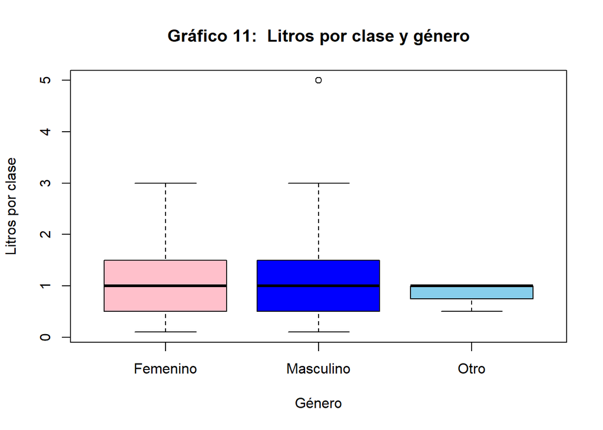

```r
boxplot(Bdatos$Litros_clase~Bdatos$Género,col=c("pink","blue","skyblue"),xlab = "Género", ylab= "Litros por clase", main = "Gráfico 11:  Litros por clase y género")
```

En esta relación existen como mínimo 1 dato atípico para el género masculino.

Se presentarán tablas para notar la mediana y moda de los litros consumidos en clase respecto a cada género:

```r
by(Bdatos$Litros_clase,Bdatos$Género,median)
```

```
## Bdatos$Género: Femenino
## [1] 1
## ------------------------------------------------------------
## Bdatos$Género: Masculino
## [1] 1
## ------------------------------------------------------------
## Bdatos$Género: Otro
## [1] 1
```

```r
table(Bdatos$Litros_clase,Bdatos$Género)
```

```
##
##         Femenino Masculino Otro
##   0.1          1         5    0
##   0.2          2         1    0
##   0.25         1         3    0
##   0.3          2         0    0
##   0.4          0         1    0
##   0.5         26        30    1
##   0.6          0         1    0
##   0.675        0         1    0
##   0.7          1         2    0
##   0.75         0         1    0
##   1           22        35    2
##   1.5          7        10    0
##   2            8         9    0
##   2.5          1         2    0
##   3            7         5    0
##   5            0         2    0
```

Al menos el 50% respecto a cada género suele consumir un litro de agua. Además, El género femenino, en su mayoría, tiende a consumir 0.5 litros de líquido menos respecto a los géneros restantes.

#### 3.0.2.3 *Tercera relación -> (Tipos_liquido (derivados) - Género)*:

Se usan tablas para conocer los tipos de líquidos que se consumen **durante el día** por género. Debido a que no se utiliza ninguna variable númerica para esta relación, se usará la moda como descriptor.

- **Consumo de agua:**

Se puede apreciar que en todos los géneros presentes, el agua es consumida en una proporción muy alta:

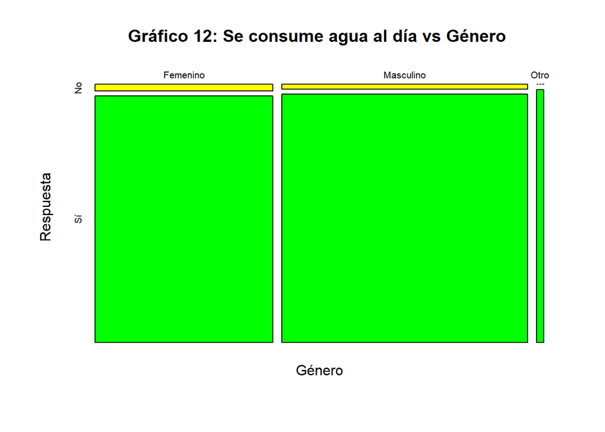

```r
suppressMessages({class(Bdatos)
attach(Bdatos)
tg <-table(Género, Agua)
mosaicplot(tg,main="Gráfico 12: Se consume agua al día vs Género ", ylab= "Respuesta",col=c("yellow","green"))})
```

- **Consumo de Gaseosas:**

Se puede apreciar que en todos los géneros presentes, la gaseosa es consumida en una proporción baja:

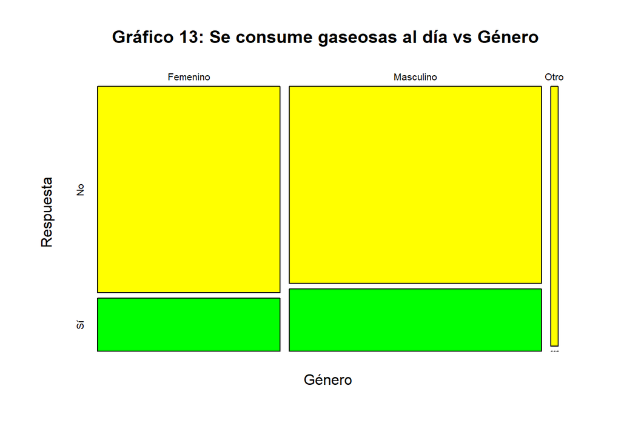

```r
suppressMessages({class(Bdatos)
attach(Bdatos)
tg <-table(Género, Gaseosas)
mosaicplot(tg,main="Gráfico 13: Se consume gaseosas al día vs Género " ,ylab="Respuesta",col=c("yellow","green"))})
```

- **Consumo de Refrescos o jugos:**

Para todos los géneros presentes, los refrescos o jugos son tanto consumidos como no consumidos en una proporción similar, siendo la moda que no consumen este tipo de bebidas:

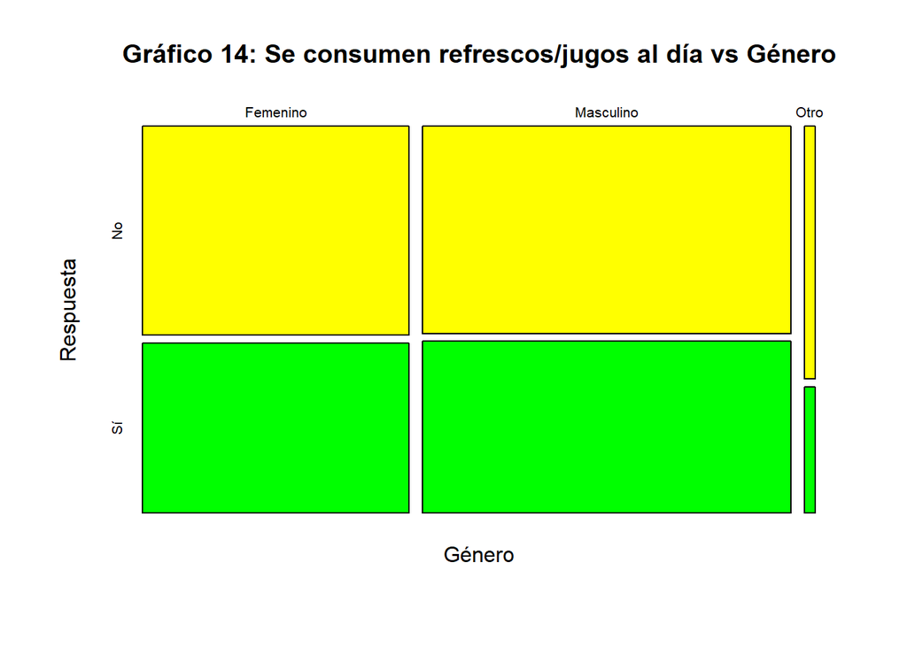

```r
suppressMessages({class(Bdatos)
attach(Bdatos)
tg <-table(Género, `Refrescos o jugos`)
mosaicplot(tg,main="Gráfico 14: Se consumen refrescos/jugos al día vs Género" ,ylab= "Respuesta",col=c("yellow","green"))})
```

```r
by(Bdatos$`Refrescos o jugos`,Bdatos$Género,Mode)
```

```
## Bdatos$Género: Femenino
## [1] "No"
## ------------------------------------------------------------
## Bdatos$Género: Masculino
## [1] "No"
## ------------------------------------------------------------
## Bdatos$Género: Otro
## [1] "No"
```

- **Consumo de Bebidas energéticas:**

Se puede apreciar que para todos los géneros presentes, las bebidas energéticas son poco consumidas.

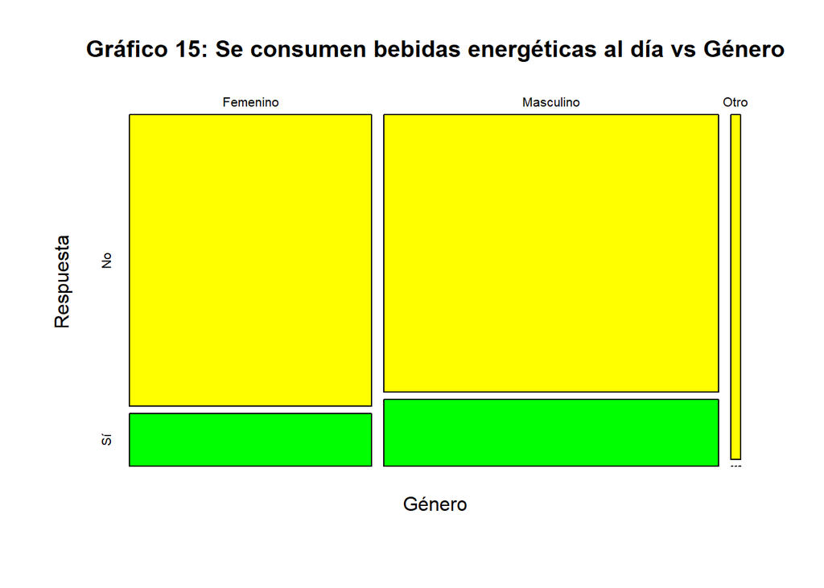

```r
suppressMessages({class(Bdatos)
attach(Bdatos)
tg <-table(Género, `Bebidas energizantes`)
mosaicplot(tg,main="Gráfico 15: Se consumen bebidas energéticas al día vs Género" ,ylab= "Respuesta",col=c("yellow","green"))})
```

- **Consumo de Infusiones:**

Se puede apreciar que para todos los géneros presentes, las infusiones son poco consumidas:

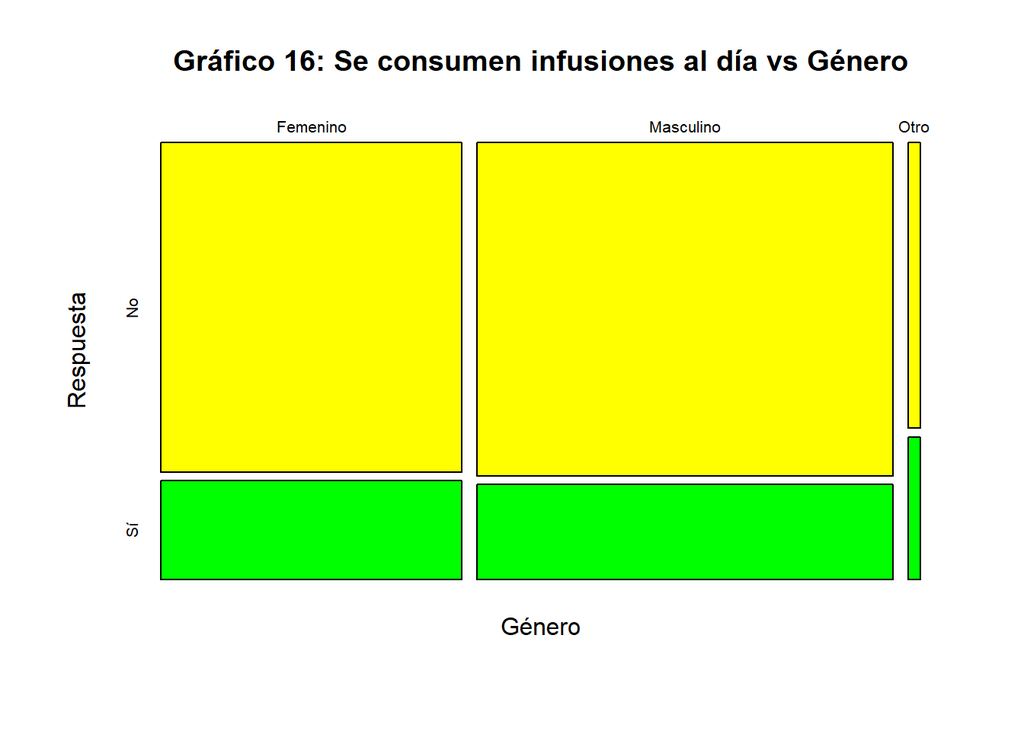

```r
suppressMessages({class(Bdatos)
attach(Bdatos)
tg <-table(Género, Infusiones)
mosaicplot(tg,main="Gráfico 16: Se consumen infusiones al día vs Género" ,ylab= "Respuesta",col=c("yellow","green"))})
```

- **Consumo de otras bebidas:**

Se puede apreciar que todos los géneros presentes no suelen consumir otro tipo de bebidas aparte de las mencionadas:

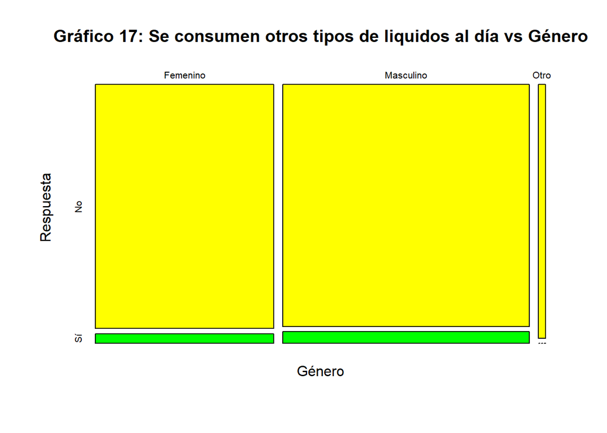

```r
suppressMessages({class(Bdatos)
attach(Bdatos)
tg <-table(Género, Otro)
mosaicplot(tg,main="Gráfico 17: Se consumen otros tipos de liquidos al día vs Género" ,ylab= "Respuesta",col=c("yellow","green"))})
```

A partir de ello, se puede notar que tanto el género masculino como el género femenino y aquellos alumnos que presentan como género “otro” tienden a tomar con mayor frecuencia agua en lugar de otras bebidas.

#### 3.0.2.4 *Cuarta relación -> (Agua_clase - Género), (Gaseosas_clase - Género), (Bebidas_energeticas_clase - Género), (Infusiones_clase - Género)*:

Se tratará de ver en que proporción se están consumiendo los líquidos representados por las varibles **durante clases**. Debido a que no se tiene ninguna variable numérica, se utilizará la moda como medida de resumen. Asimismo, se crearán tablas para apreciar mejor la distribución de los datos en cada una de estas relaciones:

**Relación: (Agua_clase - Género)**

```r
table(Bdatos$Agua_clase,Bdatos$Género)
```

```
##
##                Femenino Masculino Otro
##   A veces            24        40    1
##   Casi nunca         17        23    0
##   Casi siempre       21        23    1
##   Nunca               1         6    0
##   Siempre            15        16    1
```

Se puede notar que la categoría que más se repite en el género femenino y masculino es “A veces”. Sin embargo, no existe una categoría que se repita en mayor proporción para el género “otro”.

```r
by(Bdatos$Agua_clase,Bdatos$Género,Mode)
```

```
## Bdatos$Género: Femenino
## [1] "A veces"
## ------------------------------------------------------------
## Bdatos$Género: Masculino
## [1] "A veces"
## ------------------------------------------------------------
## Bdatos$Género: Otro
## [1] NA
```

De forma coherente con la interpretación anterior, luego de obtenida la moda también se puede notar que el género femenino y masculino, en su mayoría, consume agua “a veces” durante clases. Por otro lado, aquellos tres estudiantes que presentan como género “otro”, tienen respuestas diferentes respecto a esta variable, por lo que no existe moda.

**(Gaseosas_clase - Género)**

```r
table(Bdatos$Gaseosas_clase,Bdatos$Género)
```

```
##
##                Femenino Masculino Otro
##   A veces             4         8    0
##   Casi nunca         21        13    1
##   Casi siempre        3         5    0
##   Nunca              49        78    2
##   Siempre             1         4    0
```

Por género, la mayoría nunca consume gaseosas durante clases.

**(Bebidas_energeticas_clase - Género)**

```r
table(Bebidas_energeticas_clase,Bdatos$Género)
```

```
##
## Bebidas_energeticas_clase Femenino Masculino Otro
##              A veces             8         8    0
##              Casi nunca         10        17    0
##              Casi siempre        7         6    0
##              Nunca              52        71    3
##              Siempre             1         6    0
```

En todos los géneros presentes, lo que sucede en mayor frecuencia es que nunca consumen bebidas energéticas durante clases.

**(Infusiones_clase - Género)**

```r
table(Bdatos$Infusiones_clase,Bdatos$Género)
```

```
##
##                Femenino Masculino Otro
##   A veces            12         5    0
##   Casi nunca         17        16    1
##   Casi siempre        1         3    0
##   Nunca              46        81    2
##   Siempre             2         3    0
```

Se puede apreciar que en todos los géneros presentes, lo que sucede en mayor frecuencia es que nunca consumen infusiones durante clases.

*Conclusión* –> el agua es el tipo de líquido que más se consume durante los horarios de clase por los estudiantes de la UTEC y no existiría alguna diferencia por género en este caso.

#### 3.0.2.5 *Quinta relación -> (Cansado_tipo_liquido - Género)*:

En este caso se verán que líquidos suelen tomar los estudiantes de la UTEC por género cuando se sienten cansados.

Esta gráfica muestra los líquidos que suelen tomar los estudiantes **por género** cuando se sienten cansados:

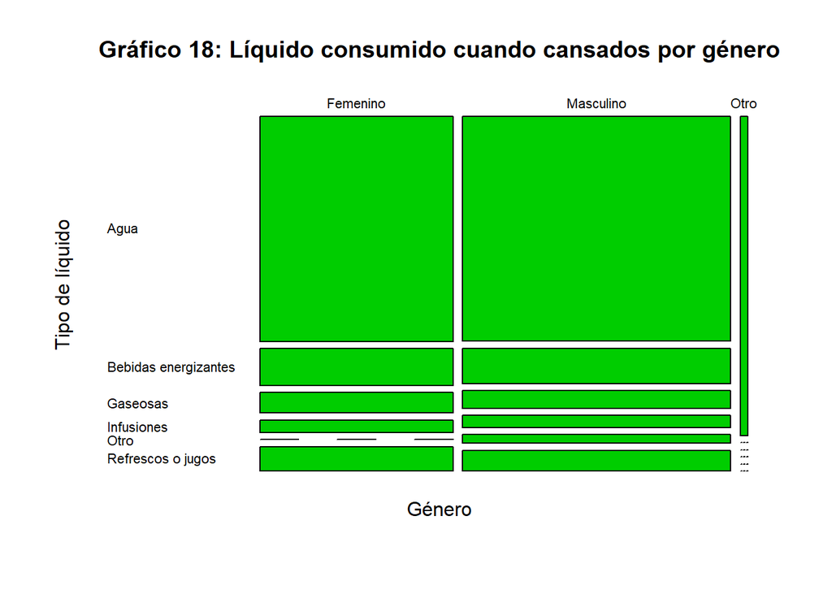

```r
suppressMessages({class(Bdatos)
attach(Bdatos)
tg <-table(Género, Cansado_tipo_liquido)
mosaicplot(tg,main="Gráfico 18: Líquido consumido cuando cansados por género", cex.axis = 0.7, las = 1, xlab = "Género", ylab = "Tipo de líquido",color="green3")})
```

Se puede apreciar que todos los géneros presentes prefieren consumir agua cuando se sienten cansados en lugar de otro tipo de líquidos, como lo podrían ser las bebidas energéticas.

#### 3.0.2.6 *Sexta relación -> (Liquido_mejora_rendimiento - Género)*:

En este caso se tratará de ver cuál es el líquido que ayuda a mejorar el rendimiento académico de los estudiantes por género.

```r
by(Bdatos$Liquido_mejora_rendimiento,Bdatos$Género,Mode)
```

```
## Bdatos$Género: Femenino
## [1] "Agua"
## ------------------------------------------------------------
## Bdatos$Género: Masculino
## [1] "Agua"
## ------------------------------------------------------------
## Bdatos$Género: Otro
## [1] "Agua"
```

En este último caso se evidencia que todos los géneros prefieren consumir agua cuando desean mejorar su rendimiento academico.

*CONLUSIONES* —> Se pudo apreciar que, en gran medida, los hábitos de hidratación de los alumnos por género son similares. Sin embargo, sí existen algunas diferencias, pero estas son mínimas:

- Cuando se trata a la cantidad de litros de liquido consumido al dia -> Se puede observar que los hombres tienden a tomar 0.5L o 1L más de líquidos durante el día que las mujeres.
- Cuando se trata de litros de líquido consumidos durante los horarios de clase -> A partir de la moda, se pudo notar que los hombres tienden a consumir a lo mucho 0.5L de líquido en mayor proporción durante los horarios de clases que las mujeres.

### 3.0.3 Estimar los posibles efectos negativos de una mala hidratación en la salud física y mental en los estudiantes por género

En este caso, “para vivir y respirar, […], se requiere la ingesta de aproximadamente 2.5 litros de líquido al día” (Ojeda, 2015, p. 37). Con esto se puede entender que un alumno bien hidratado debería consumir como mínimo 2.5 litros de líquidos. Es importante destacar que una ingesta de 3 litros de agua diarios es todavía considerado aceptable. Sin embargo, ingestas mayores a las mencionadas pueden causar problemas en la salud, así como ingestas menores a 2.5 litros diarios. A partir de esta información se analizarán los datos registrados.

- En primer lugar se analizarán a los alumnos mal hidratados (hiperhidratación o deshidratación):

```r
filter(Bdatos,Litros_por_dia<2.5 | Litros_por_dia>3)
```

```
## # A tibble: 123 x 34
##     Edad Género   Carrera Ciclo Litros_por_dia Litros_clase Sed_clase Agua_clase
##    <dbl> <chr>    <chr>   <chr>          <dbl>        <dbl> <chr>     <chr>
##  1    23 Otro     Ingeni~ Quin~           1.05          0.5 Ni mucha~ A veces
##  2    18 Femenino Cienci~ Terc~           1.5           0.5 Poca      Casi nunca
##  3    18 Femenino Ingeni~ Cuar~           4             2   Mucha     Siempre
##  4    17 Masculi~ Ingeni~ Segu~           2             1   Ni mucha~ Casi nunca
##  5    19 Masculi~ Ingeni~ Segu~           2             1   Ni mucha~ Casi nunca
##  6    18 Femenino Ingeni~ Terc~           1             0.5 Poca      A veces
##  7    19 Masculi~ Ingeni~ Déci~           2             1   Muy poca  Casi nunca
##  8    18 Femenino Bioing~ Terc~           2             1   Moderada  Siempre
##  9    21 Femenino Ingeni~ Cuar~           2             1.5 Ni mucha~ A veces
## 10    18 Otro     Cienci~ Cuar~           1             1   Ni mucha~ Casi siem~
## # i 113 more rows
## # i 26 more variables: Gaseosas_clase <chr>, Bebidas_energeticas_clase <chr>,
## #   Infusiones_clase <chr>, Cansado_tipo_liquido <chr>,
## #   Liquido_mejora_rendimiento <chr>, Rendimiento_hidratado <chr>,
## #   Concentracion_clase <chr>, Memoria <chr>, Deshidratacion_efectos <chr>,
## #   Salud_fisica <chr>, Migrañas <chr>, Fatiga <chr>, Salud_mental <chr>,
## #   Ansiedad <chr>, Estres <chr>, CF_no_ingesta_liquido <chr>, Peso <dbl>, ...
```

```r
round((nrow(filter(Bdatos,Litros_por_dia<2.5 | Litros_por_dia>3))/nrow(Bdatos))*100,2)
```

```
## [1] 65.08
```

Se puede notar que la cantidad de estudiantes que presentan una mala hidratación son 123, los cuales representan al 65.08% de las observaciones.

- Se verá si estos estudiantes (por género) sufren efectos negativos debido a su mala hidratación a partir de los siguientes análisis:

**Problemas en su salud física**

1. Presencia de mucha sed durante los horarios de clase
2. Concentración que tienen durante clases
3. Presencia de migrañas
4. Presencia de fatiga
5. Su memoria

**Problemas en su salud mental**

6. Presencia de mucho estrés
7. Presencia de mucha ansiedad

**Salud física**

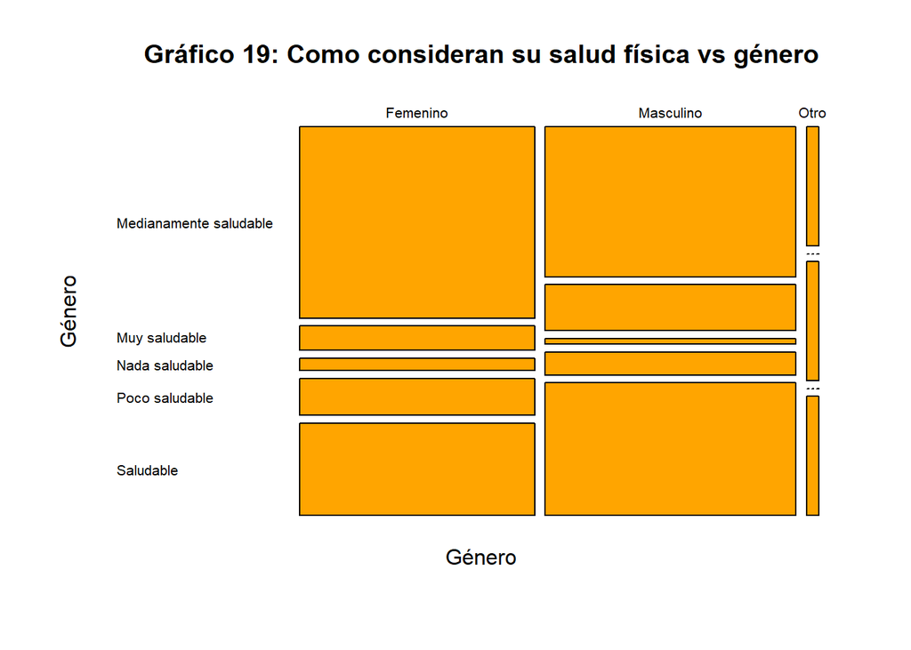

```r
suppressMessages({class(filter(Bdatos,Litros_por_dia<2.5 | Litros_por_dia>3))
attach(filter(Bdatos,Litros_por_dia<2.5 | Litros_por_dia>3))
tg <-table(Género, Salud_fisica)
mosaicplot(tg,main="Gráfico 19: Como consideran su salud física vs género",ylab="Género",col="orange1", las = 1)})
```

En los géneros femenino y masculino del grupo de estudiantes mal hidratado, la mayoría se considera medianamente saludable.

**1. Sed durante clase**

La sed es comunmente un indicio de deshidratación:

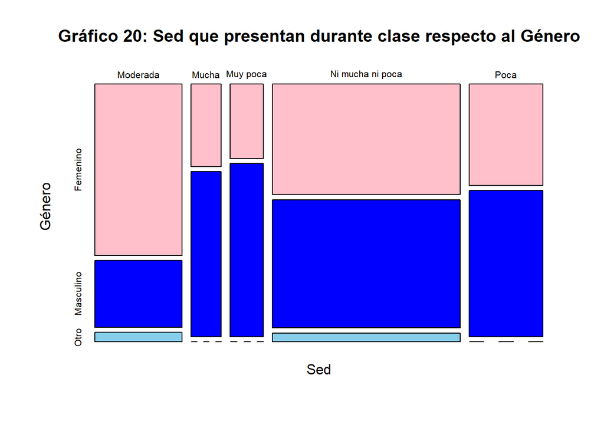

```r
suppressMessages({class(filter(Bdatos,Litros_por_dia<2.5 | Litros_por_dia>3))
attach(filter(Bdatos,Litros_por_dia<2.5 | Litros_por_dia>3))
tg <-table(Sed_clase, Género)
mosaicplot(tg,main="Gráfico 20: Sed que presentan durante clase respecto al Género",ylab="Género",col=c("pink","blue","skyblue"), xlab = "Sed")})
```

Como se puede notar, en todos los géneros de este grupo, la mayoría no presenta ni mucha ni poca sed durante clases.

**2. Concentración**

Está comprobado cientificamente que presentar malos hábitos de hidratación disminuye las funciones cognitivas:

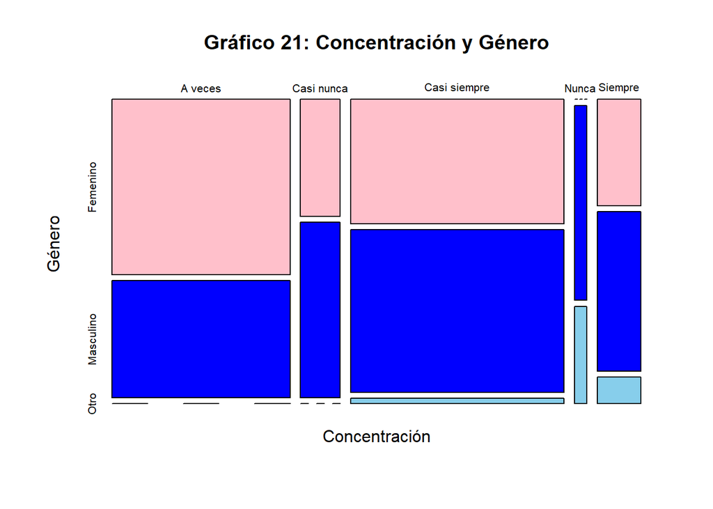

```r
suppressMessages({class(filter(Bdatos,Litros_por_dia<2.5 | Litros_por_dia>3))
attach(filter(Bdatos,Litros_por_dia<2.5 | Litros_por_dia>3))
tg <-table(Concentracion_clase, Género)

mosaicplot(tg,main="Gráfico 21: Concentración y Género",ylab="Género", xlab ="Concentración",col=c("pink","blue","skyblue"))})
```

**3. Migrañas**

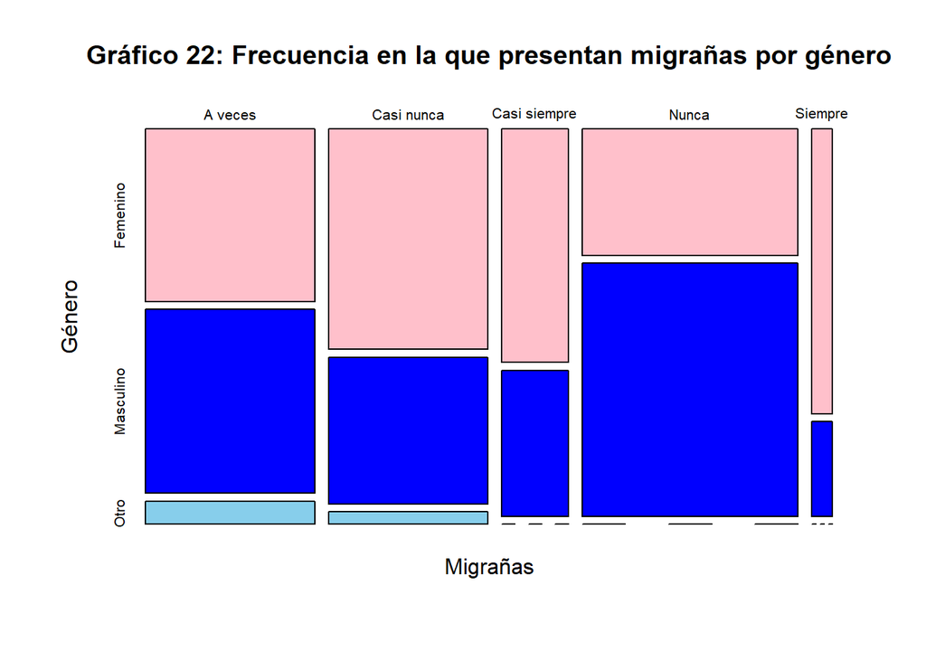

```r
suppressMessages({class(filter(Bdatos,Litros_por_dia<2.5 | Litros_por_dia>3))
attach(filter(Bdatos,Litros_por_dia<2.5 | Litros_por_dia>3))
tg <-table(Migrañas, Género)
mosaicplot(tg,main="Gráfico 22: Frecuencia en la que presentan migrañas por género",ylab="Género",col=c("pink","blue","skyblue"))})
```

**4. Fatiga**

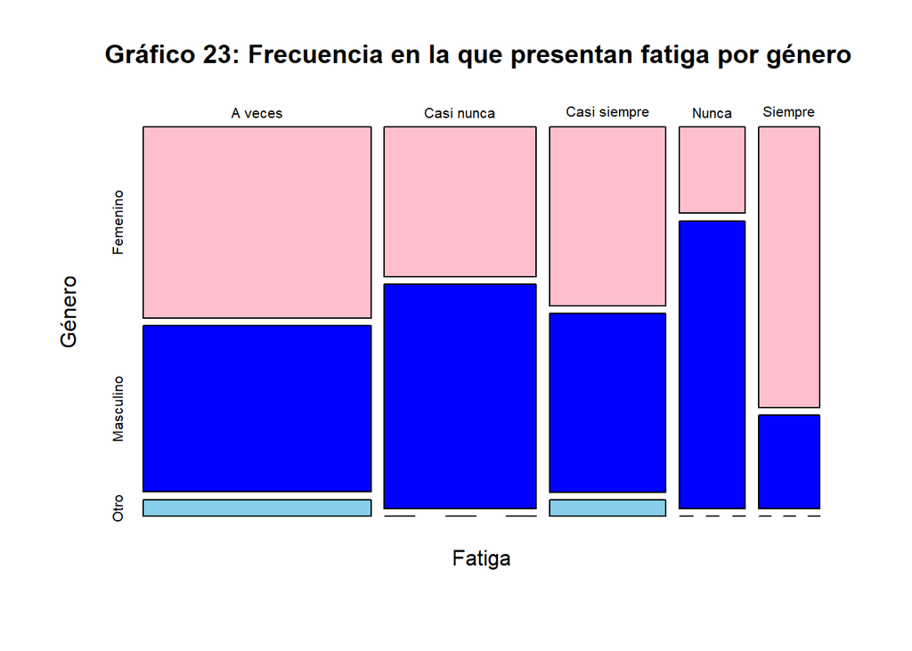

```r
suppressMessages({class(filter(Bdatos,Litros_por_dia<2.5 | Litros_por_dia>3))
attach(filter(Bdatos,Litros_por_dia<2.5 | Litros_por_dia>3))
tg <-table(Fatiga, Género)
mosaicplot(tg,main="Gráfico 23: Frecuencia en la que presentan fatiga por género ",ylab="Género",col=c("pink","blue","skyblue"))})
```

Por género, la mayoría presente fatiga a veces, en especial el género femenino.

**5. Memoria**

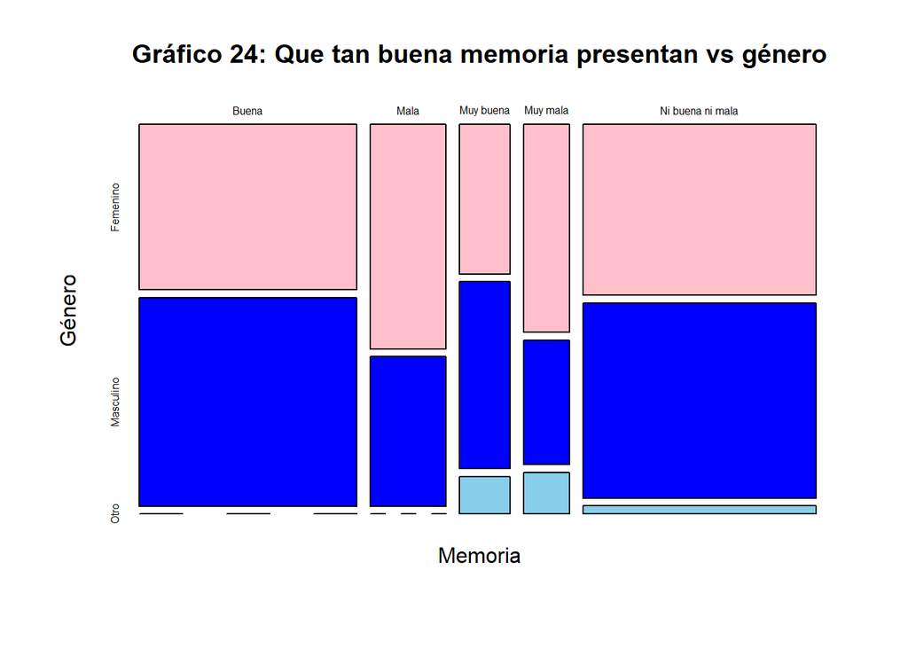

```r
suppressMessages({class(filter(Bdatos,Litros_por_dia<2.5 | Litros_por_dia>3))
attach(filter(Bdatos,Litros_por_dia<2.5 | Litros_por_dia>3))
tg <-table(Memoria, Género)
mosaicplot(tg,main="Gráfico 24: Que tan buena memoria presentan vs género",ylab="Género",col=c("pink","blue","skyblue"), cex.axis = 0.5)})
```

Los géneros femenino y masculino consideran, en su mayoría, que tienen o una buena memoria o una ni buena ni mala memoria.

*CONLUSIONES* —> A partir de estos resultados, no se puede afirmar por completo que los estudiantes que presentan malos hábitos de hidratación presentan efectos negativos fisicamente. Sin embargo, se muestran ciertos indicios, gracias a las variables analizadas, de que estos estudiantes están empezando a presentar algunos impactos en su salud, sobre todo para los de género femenino.

**Salud mental**

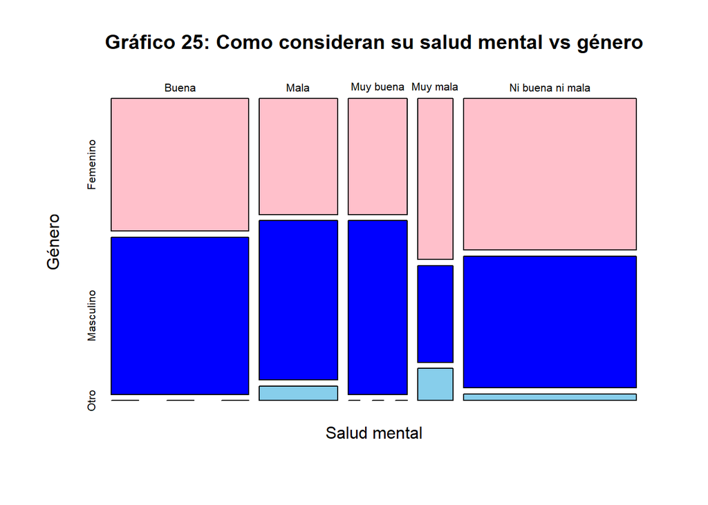

```r
suppressMessages({class(filter(Bdatos,Litros_por_dia<2.5 | Litros_por_dia>3))
attach(filter(Bdatos,Litros_por_dia<2.5 | Litros_por_dia>3))
tg <-table(Salud_mental, Género)
mosaicplot(tg,main="Gráfico 25: Como consideran su salud mental vs género",ylab="Género",col=c("pink","blue","skyblue"), xlab="Salud mental")})
```

Por género, la mayoría considera que su salud mental se encuentra en un nivel “ni bueno ni malo”.

**6. Estrés**

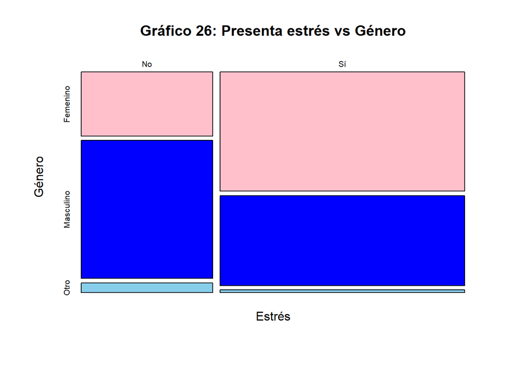

```r
suppressMessages({class(filter(Bdatos,Litros_por_dia<2.5 | Litros_por_dia>3))
attach(filter(Bdatos,Litros_por_dia<2.5 | Litros_por_dia>3))
tg <-table(Estres, Género)
mosaicplot(tg,main="Gráfico 26: Presenta estrés vs Género",ylab="Género", xlab="Estrés",col=c("pink","blue","skyblue"))})
```

El género femenino presenta mayores niveles de estrés, a comparación con los demás géneros, del grupo de estudiantes con malos hábitos de hidratación.

**7. Ansiedad**

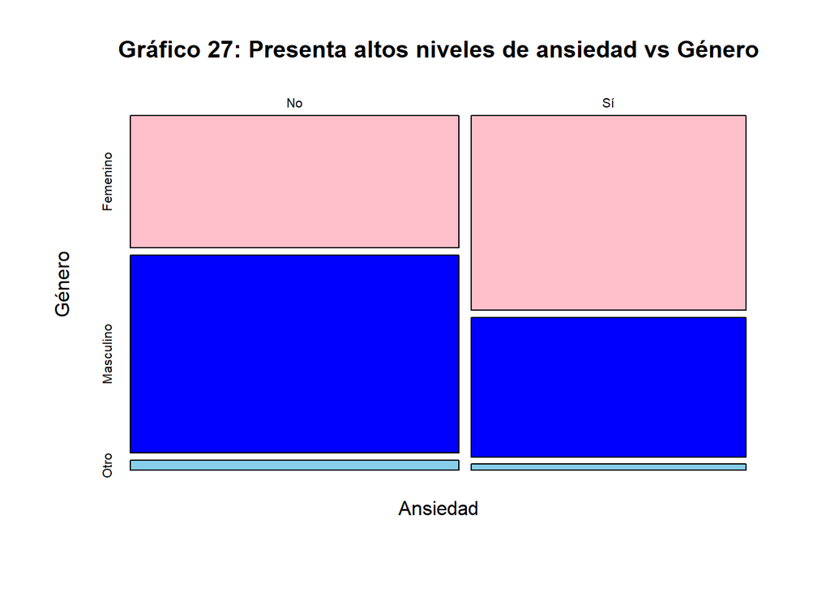

```r
suppressMessages({class(filter(Bdatos,Litros_por_dia<2.5 | Litros_por_dia>3))
attach(filter(Bdatos,Litros_por_dia<2.5 | Litros_por_dia>3))
tg <-table(Ansiedad, Género)
mosaicplot(tg,main="Gráfico 27: Presenta altos niveles de ansiedad vs Género",ylab="Género",col=c("pink","blue","skyblue"))})
```

*CONLUSIONES* —> Se puede notar que estos estudiantes, especialmente los de género femenino, están comenzando a presentar efectos nocivos en su salud mental.

**Datos adicionales de la muestra:**

Aquí se verá la opinion de los alumnos mal hidratados con respecto a las siguientes preguntas:

- ¿Se siente cansado o fatigado cuando no consume líquidos con frecuencia?

```r
table((filter(Bdatos,Litros_por_dia<2.5 | Litros_por_dia>3))$CF_no_ingesta_liquido)
```

```
##
## A veces      No      Si
##      37      25      61
```

```r
round((61/sum(table((filter(Bdatos,Litros_por_dia<2.5 | Litros_por_dia>3))$CF_no_ingesta_liquido)))*100,2)
```

```
## [1] 49.59
```

El 49.59% de ellos afirma sentirse fatigado o cansado cuando no consumen liquidos con frecuencia.

- ¿Usted cree que la deshidratación afecta en sus aspectos cognitivos, como en la atención o concentración?

```r
table((filter(Bdatos,Litros_por_dia<2.5 | Litros_por_dia>3))$Deshidratacion_efectos)
```

```
##
##      No      Si Tal vez
##      10      86      27
```

```r
round((86/sum(table((filter(Bdatos,Litros_por_dia<2.5 | Litros_por_dia>3))$Deshidratacion_efectos)))*100,2)
```

```
## [1] 69.92
```

El 69.92% de ellos opina que la deshidratación sí afecta en su concentración.

- ¿Considera que el mantenerse hidratado afecta en su rendimiento académico?

```r
table((filter(Bdatos,Litros_por_dia<2.5 | Litros_por_dia>3))$Rendimiento_hidratado)
```

```
##
##      No      Sí Tal vez
##      25      78      20
```

```r
round((78/sum(table((filter(Bdatos,Litros_por_dia<2.5 | Litros_por_dia>3))$Rendimiento_hidratado)))*100,2)
```

```
## [1] 63.41
```

Se puede ver que el 63.41% de ellos opina que el mantenerse hidratados sí afecta en su rendimiento académico.

*CONCLUSION* —> Existen ciertos indicios que indican que la salud física y mental de los alumnos se ve afectada, sobre todo para el género femenino. Sin embargo, los resultados obtenidos, al no presentar un patrón fuerte, no pueden ser del todo confirmatorios. Ello puede ser debido a factores externos no considerados en el estudio. Asimismo, se puede notar que la mayoría de estos alumnos reconoce que una mala hidratación conlleva a efectos negativos en su salud y, por lo tanto, en su rendimiento académico.